# Breaches During Covid

Matthew Webb

2024-02-05

## About Project

This is a brief tutorial relating to ggplot and how to add annotations and text to a chart to help explain the visualization

We will be using A&E Admissions data, specifically the 4 Hour and 12 Hour Breaches variables

A breach occurs when a patient remains in A&E without being discharged or admitted for 4 hours, and then a second breach occurs if they remain in A&E for over 12 hours.

First we need to load in the required packages

```r
library(httr)
library(tidyverse)
library(janitor)
library(readxl)
library(here)
library(gt)
```

```r
library(ggplot2)
```

## Loading in the data

We need to source where our data is coming from, the below URL is from the NHS England Website and relates to the publicly available A&E data from August-2010 to September-2023

Save a copy into your project folder and then read it into R

We also need to tell R what part of the workbook we wish to use for our analysis, and define the column types

```r
# We define the URL first from the website
data_url <- 'https://view.officeapps.live.com/op/view.aspx?src=https%3A%2F%2Fwww.england.nhs.uk%2Fstatistics%2Fwp-content%2Fuploads%2Fsites%2F2%2F2023%2F10%2FMonthly-AE-Time-Series-September-2023.xls&wdOrigin=BROWSELINK'


# Then we load that data into R with 'read_excel' and tell it what part of the workbook we want
Monthly_Data <- read_excel(path = here('Monthly-AE-Time-Series-September-2023.xlsx'), sheet = 1, range = "B14:N172",
  col_names = TRUE,
  col_types = c("date","numeric","numeric","numeric",
              "numeric","numeric","numeric", "numeric",
              "numeric","numeric","numeric", "numeric",
              "numeric"), skip = 13) |>
  clean_names()
```

## Formatting the columns

Next we need to format our columns and select the ones we want to use

When you import data into R the date variables are defined as POSIX date, so we can format them into standard R date format

```r
Monthly_Data_Formatted <- Monthly_Data |>
# Formatting variables to integers and renaming to make them more manageable
  mutate(
    `Total Attendances` = as.integer(total_attendances),
    `Total Emergency Admissions` = as.integer(total_emergency_admissions),
    `4 Hour Breaches` = as.integer(number_of_patients_spending_4_hours_from_decision_to_admit_to_admission),
    `12 Hour Breaches` = as.integer(number_of_patients_spending_12_hours_from_decision_to_admit_to_admission),
    `Period Formatted` = as.Date(period),
# We're creating a 'Year' variable based off of the 'Period Formatted' variable we made above
    `Year` = year(`Period Formatted`)) |>
# Keeping the formatted columns
  select(`Period Formatted`,
         `Year`,
         `Total Attendances`,
         `Total Emergency Admissions`,
         `4 Hour Breaches`,
         `12 Hour Breaches`) |>
  view()
```

## Overview Table

It’s useful to create an initial table to get an idea of the overall trends

We can group by the new ‘Year’ variable to get aggregate counts

```r
Yearly_Table <- Monthly_Data_Formatted |>
  group_by(`Year`) |>
  summarise(
    `Total Emergency Admissions` = sum(`Total Emergency Admissions`),
    `4 Hour Breaches` = sum(`4 Hour Breaches`),
    `12 Hour Breaches` = sum(`12 Hour Breaches`)
  ) |>
  gt() |>
  tab_header(title = md("**Total A&E Breaches in England 2010-2023**"),
             subtitle = md("Both 4-Hour and 12-Hour Breaches")) |>
  tab_source_note(source_note = "Source: NHS England A&E Monthly Statistics") |>
# This part formas the selected columns by choosing the delimiter and number of decimals
  fmt_number(columns = c(`Total Emergency Admissions`,`4 Hour Breaches`, `12 Hour Breaches`),
             sep_mark = ",",
             decimals = 0)

Yearly_Table
```

**Total A&E Breaches in England 2010-2023**

Both 4-Hour and 12-Hour Breaches

| Year | Total Emergency Admissions | 4 Hour Breaches | 12 Hour Breaches |
| --- | --- | --- | --- |
| 2010 | 2,168,644 | 37,533 | 16 |
| 2011 | 5,098,625 | 98,589 | 122 |
| 2012 | 5,229,851 | 129,828 | 31 |
| 2013 | 5,238,148 | 178,586 | 254 |
| 2014 | 5,480,266 | 250,288 | 484 |
| 2015 | 5,577,322 | 341,269 | 1,203 |
| 2016 | 5,792,190 | 538,358 | 2,600 |
| 2017 | 5,937,314 | 565,495 | 2,792 |
| 2018 | 6,272,917 | 637,977 | 4,059 |
| 2019 | 6,533,310 | 847,418 | 8,272 |
| 2020 | 5,483,753 | 604,015 | 14,258 |
| 2021 | 6,027,743 | 1,029,235 | 48,626 |
| 2022 | 5,978,113 | 1,623,036 | 348,135 |
| 2023 | 4,638,947 | 1,118,623 | 288,253 |

Source: NHS England A&E Monthly Statistics

## A simple plot with title labels

Now we have an idea of the trends we can start visualising

This will be a simple line plot showing total emergency admissions

We define our data we want to use for the graph, and then define our x and y axes

We can also include a title and axis labels

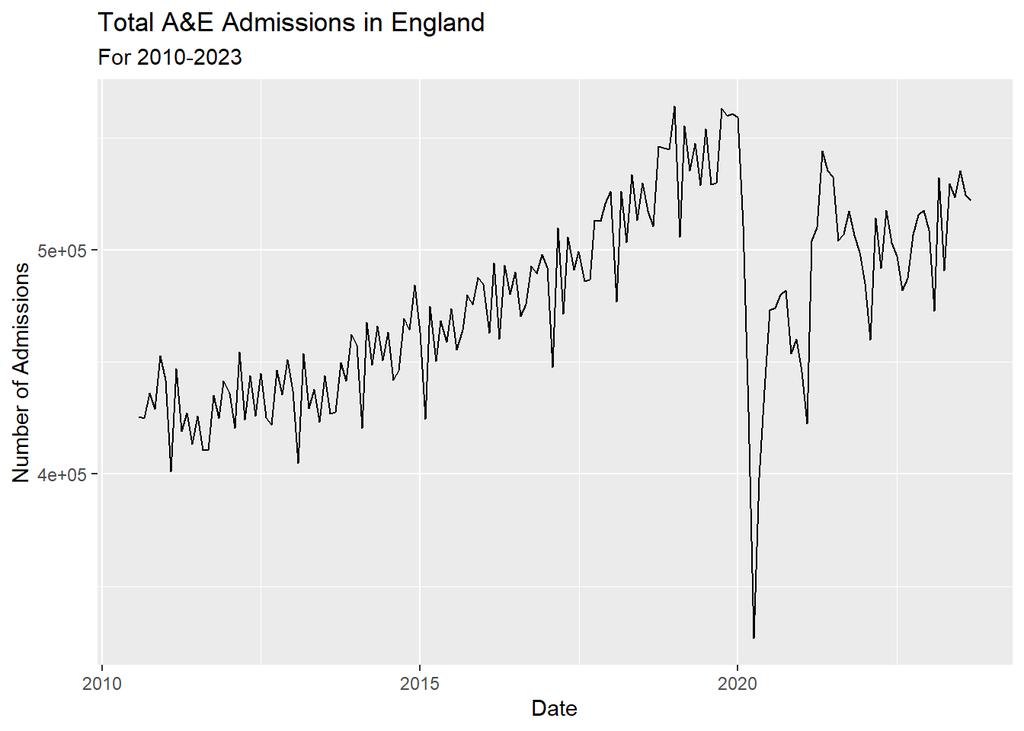

```r
Simple_Plot <- ggplot(Monthly_Data_Formatted, aes(x = `Period Formatted`, y = `Total Emergency Admissions`)) +
  geom_line() +
  labs(title = "Total A&E Admissions in England",
       subtitle = "For 2010-2023",
       x = "Date",
       y = "Number of Admissions")
Simple_Plot
```

## Applying a scale to the x axis

As you can see this graph is very basic, so lets start improving it

Currently the x axis is only showing 3 years, we can change this by adding a scale

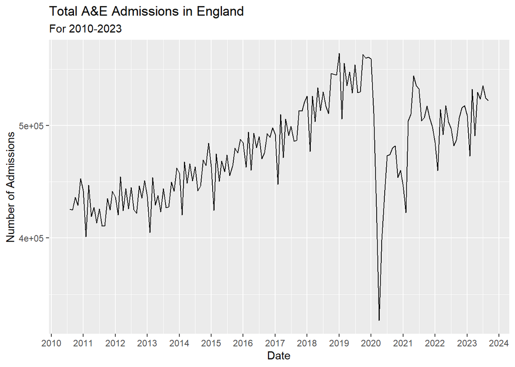

```r
Simple_Plot_Dates <- ggplot(Monthly_Data_Formatted, aes(x = `Period Formatted`, y = `Total Emergency Admissions`)) +
  geom_line() +
  labs(title = "Total A&E Admissions in England",
       subtitle = "For 2010-2023",
       x = "Date",
       y = "Number of Admissions") +
# We can simply add our scale onto the graph by including the 'scale_x_date' condition
  scale_x_date(date_labels = "%Y", date_breaks = "1 year")

Simple_Plot_Dates
```

## Creating initial breaches plot

Now we know how to plot a line we swap out the Total Admissions for our 4 and 12 Hour Admissions and add some colour to distinguish the two lines

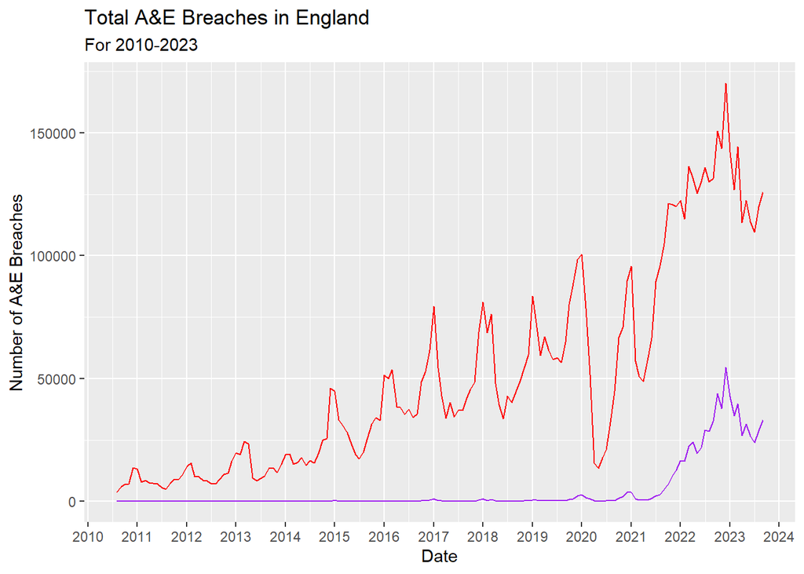

```r
Simple_Breaches_Plot <- ggplot(Monthly_Data_Formatted, aes(x = `Period Formatted`, y = `4 Hour Breaches`)) +
# This first geom_line represents the 4 Hour line we detailed in the ggplot condition
  geom_line(colour = "red", size = 0.5) +
# Then to add a second line we simply add another geom_line condition and specify the variables
  geom_line(aes(x = `Period Formatted`, y = `12 Hour Breaches`), colour = "purple", size = 0.5) +
  labs(title = "Total A&E Breaches in England",
       subtitle = "For 2010-2023",
       x = "Date",
       y = "Number of A&E Breaches") +
  scale_x_date(date_labels = "%Y", date_breaks = "1 year")
Simple_Breaches_Plot
```

## Adding annotations

We can now add some annotations to help visualise this plot better

We can highlight the COVID period with a rectangle zone, so we need to know a few details about the pandemic:

COVID-19 was officially confirmed to be in the UK in January 2020

It spread throughout the UK and in July 2021 the delta variant began spreading

So we can define the COVID period as being roughly from January 2020 to December 2021

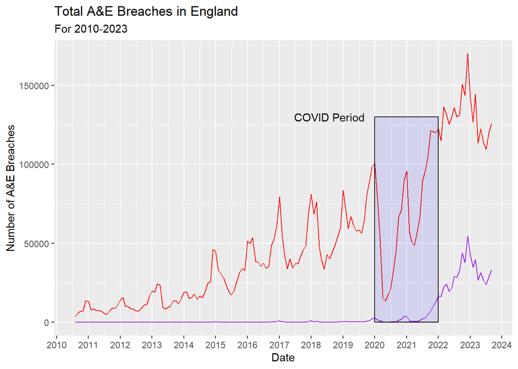

```r
Annotated_Breaches_Plot <- ggplot(Monthly_Data_Formatted, aes(x = `Period Formatted`, y = `4 Hour Breaches`)) +
  geom_line(colour = "red", size = 0.5) +
  geom_line(aes(x = `Period Formatted`, y = `12 Hour Breaches`), colour = "purple", size = 0.5) +
  labs(title = "Total A&E Breaches in England",
       subtitle = "For 2010-2023",
       x = "Date",
       y = "Number of A&E Breaches") +
  scale_x_date(date_labels = "%Y", date_breaks = "1 year") +
# The 'annotate' condition is used to place a rectangle on the graph, the x asis defines the width and the y defines the height
  annotate('rect', xmin = as.Date("2020-01-01"), xmax = as.Date("2021-12-31"), ymin = 0, ymax = 130000,
           alpha = 0.1, fill = "blue", col = "black") +
# Here we add some text to the graph to indicate what the rectangle is showing us
  annotate('text', x = as.Date("2018-08-01"), y = 130000, label = "COVID Period")

Annotated_Breaches_Plot
```

## Adding an arrow

Lets add an arrow to the label to make it clearer

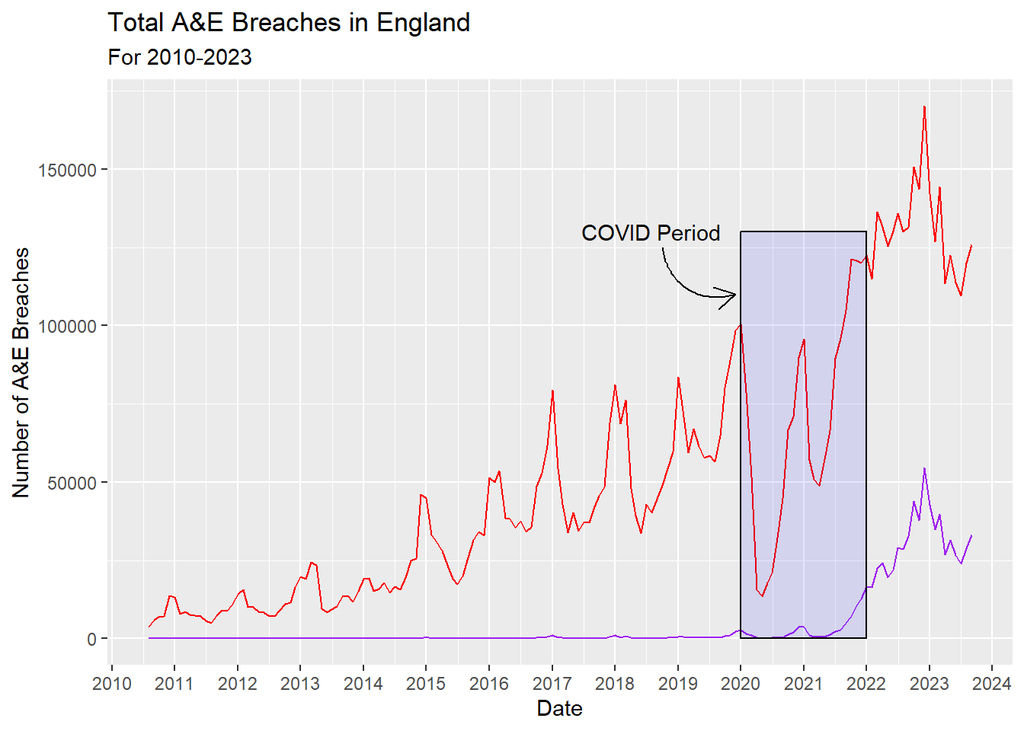

```r
Arrow_Breaches_Plot <- ggplot(Monthly_Data_Formatted, aes(x = `Period Formatted`, y = `4 Hour Breaches`)) +
  geom_line(colour = "red", size = 0.5) +
  geom_line(aes(x = `Period Formatted`, y = `12 Hour Breaches`), colour = "purple", size = 0.5) +
  labs(title = "Total A&E Breaches in England",
       subtitle = "For 2010-2023",
       x = "Date",
       y = "Number of A&E Breaches") +
  scale_x_date(date_labels = "%Y", date_breaks = "1 year")+
  annotate('rect', xmin = as.Date("2020-01-01"), xmax = as.Date("2021-12-31"), ymin = 0, ymax = 130000,
           alpha = 0.1, fill = "blue", col = "black") +
  annotate('text', x = as.Date("2018-08-01"), y = 130000, label = "COVID Period") +
# We use 'annotate' again and using the same syntax as the box we now define the arrow's curve and length
   annotate('curve', x = as.Date("2018-10-01"), xend = as.Date("2019-12-01"),
            y = 125000, yend = 110000, linewidth = 0.5, curvature = 0.5,
             arrow = arrow(length = unit(0.4,'cm')))

Arrow_Breaches_Plot
```

## Adding events to the COVID Period

There are some events that will help illustrate the COVID Period, they come from the government website:

https://www.gov.uk/government/publications/covid-19-and-occupational-impacts/covid-19-and-occupational-impacts#:~:text=Pandemic%20in%20the%20UK.,of%20SARS%2DCoV%2D2%20.

- National lockdowns were late March 2020 - June 2020 and January 2021 – July 2021
- First lockdown March 2020
- Second lockdown November 2020
- Third lockdown January 2021
- Most restrictions removed July 2021

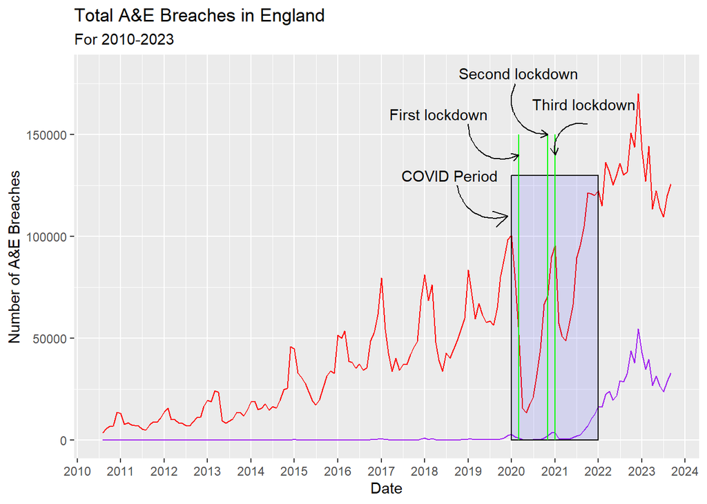

```r
Line_Breaches_Plot <- ggplot(Monthly_Data_Formatted, aes(x = `Period Formatted`, y = `4 Hour Breaches`)) +
  geom_line(colour = "red", size = 0.5) +
  geom_line(aes(x = `Period Formatted`, y = `12 Hour Breaches`), colour = "purple", size = 0.5) +
  labs(title = "Total A&E Breaches in England",
       subtitle = "For 2010-2023",
       x = "Date",
       y = "Number of A&E Breaches") +
  scale_x_date(date_labels = "%Y", date_breaks = "1 year")+
  annotate('rect', xmin = as.Date("2020-01-01"), xmax = as.Date("2021-12-31"), ymin = 0, ymax = 130000,
           alpha = 0.1, fill = "blue", col = "black") +
  annotate('text', x = as.Date("2018-08-01"), y = 130000, label = "COVID Period") +
# We use 'annotate' again and using the same syntax as the box we now define the arrow's curve and length
   annotate('curve', x = as.Date("2018-10-01"), xend = as.Date("2019-12-01"),
            y = 125000, yend = 110000, linewidth = 0.5, curvature = 0.5,
             arrow = arrow(length = unit(0.4,'cm'))) +
# Below is the code for adding the vertical lines, again using the axes to determine their positions
  geom_segment(aes(x = as.Date("2020-03-01"), y = 0, yend = 150000,
                     xend = as.Date("2020-03-01"), colour = "segment"),
                     linewidth = 0.5, colour="green") +
  geom_segment(aes(x = as.Date("2020-11-01"), y = 0, yend = 150000,
                     xend = as.Date("2020-11-01"), colour = "segment"),
                     linewidth = 0.5, colour="green") +
  geom_segment(aes(x = as.Date("2021-01-01"), y = 0, yend = 150000,
                     xend = as.Date("2021-01-01"), colour = "segment"),
                     linewidth = 0.5, colour="green") +
# Here we add labels to distinguish the lines
  annotate('text',x = as.Date("2018-05-01"),y = 160000,label = "First lockdown") +
    annotate('text',x = as.Date("2020-03-01"),y = 180000,label = "Second lockdown") +
    annotate('text',x = as.Date("2021-09-01"),y = 165000,label = "Third lockdown") +
# And now add the arrows to make it clear which is which
   annotate('curve',x = as.Date("2019-01-01"),xend = as.Date("2020-03-01"), y = 155000, yend = 140000 ,
    linewidth = 0.5,curvature = 0.6,arrow = arrow(length = unit(0.2,'cm'))) +
     annotate('curve',x = as.Date("2020-02-01"),xend = as.Date("2020-11-01"), y = 175000, yend = 150000,
    linewidth = 0.5,curvature = 0.6,arrow = arrow(length = unit(0.2,'cm'))) +
   annotate('curve',x = as.Date("2021-10-01"),xend = as.Date("2021-01-01"), y = 155000 , yend = 140000,
    linewidth = 0.5,curvature = 0.6,arrow = arrow(length = unit(0.2,'cm')))

Line_Breaches_Plot
```

## Adding a theme to the plot

Now that we have our visualisation the final step is to make it more presentable by adding a theme

We also want to add a legend so we need to prepare the plot for that

First create a COLOURS object that sorts what the colours in the legend denote

Then we move the colour argument inside the aes() in order to provide a legend to the plot

Then we add a ‘scale_colour_manual’ argument into the plot, giving it the values and the name of the legend we want

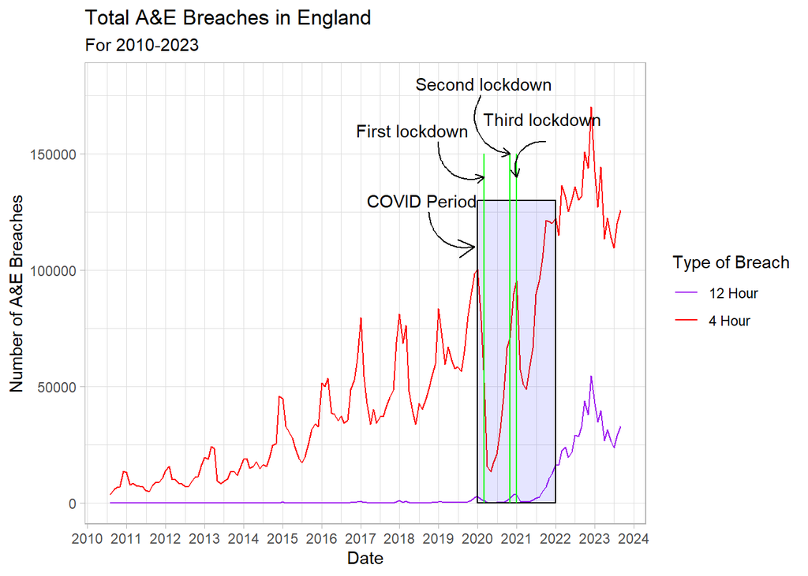

```r
# Creating our colours object
COLOURS <- c("4 Hour" = "red", "12 Hour" = "purple")

Themed_Breaches_Plot <- ggplot(Monthly_Data_Formatted) +
# We replace the colours in the aes() argument with their new names above
  geom_line(aes(x = `Period Formatted`, y = `4 Hour Breaches`, colour = "4 Hour"), size = 0.5) +
  geom_line(aes(x = `Period Formatted`, y = `12 Hour Breaches`, colour = "12 Hour"), size = 0.5) +
# Add the scale_colour_manual argument here
  scale_color_manual(values = COLOURS, name = "Type of Breach") +
  labs(title = "Total A&E Breaches in England",
       subtitle = "For 2010-2023",
       x = "Date",
       y = "Number of A&E Breaches") +
  scale_x_date(date_labels = "%Y", date_breaks = "1 year")+
  annotate('rect', xmin = as.Date("2020-01-01"), xmax = as.Date("2021-12-31"), ymin = 0, ymax = 130000,
           alpha = 0.1, fill = "blue", col = "black") +
  annotate('text', x = as.Date("2018-08-01"), y = 130000, label = "COVID Period") +
# We use 'annotate' again and using the same syntax as the box we now define the arrow's curve and length
   annotate('curve', x = as.Date("2018-10-01"), xend = as.Date("2019-12-01"),
            y = 125000, yend = 110000, linewidth = 0.5, curvature = 0.5,
             arrow = arrow(length = unit(0.4,'cm'))) +
# Below is the code for adding the vertical lines, again using the axes to determine their positions
  geom_segment(aes(x = as.Date("2020-03-01"), y = 0, yend = 150000,
                     xend = as.Date("2020-03-01"), colour = "segment"),
                     linewidth = 0.5, colour="green") +
  geom_segment(aes(x = as.Date("2020-11-01"), y = 0, yend = 150000,
                     xend = as.Date("2020-11-01"), colour = "segment"),
                     linewidth = 0.5, colour="green") +
  geom_segment(aes(x = as.Date("2021-01-01"), y = 0, yend = 150000,
                     xend = as.Date("2021-01-01"), colour = "segment"),
                     linewidth = 0.5, colour="green") +
# Here we add labels to distinguish the lines
  annotate('text',x = as.Date("2018-05-01"),y = 160000,label = "First lockdown") +
    annotate('text',x = as.Date("2020-03-01"),y = 180000,label = "Second lockdown") +
    annotate('text',x = as.Date("2021-09-01"),y = 165000,label = "Third lockdown") +
# And now add the arrows to make it clear which is which
   annotate('curve',x = as.Date("2019-01-01"),xend = as.Date("2020-03-01"), y = 155000, yend = 140000 ,
    linewidth = 0.5,curvature = 0.6,arrow = arrow(length = unit(0.2,'cm'))) +
     annotate('curve',x = as.Date("2020-02-01"),xend = as.Date("2020-11-01"), y = 175000, yend = 150000,
    linewidth = 0.5,curvature = 0.6,arrow = arrow(length = unit(0.2,'cm'))) +
   annotate('curve',x = as.Date("2021-10-01"),xend = as.Date("2021-01-01"), y = 155000 , yend = 140000,
    linewidth = 0.5,curvature = 0.6,arrow = arrow(length = unit(0.2,'cm'))) +
# We can start by adding a type of theme here, in this case 'light'
  theme_light()


Themed_Breaches_Plot
```

## Adding a legend to the plot

Now to clean up the legend and add some more details to the theme and we will have a final plot

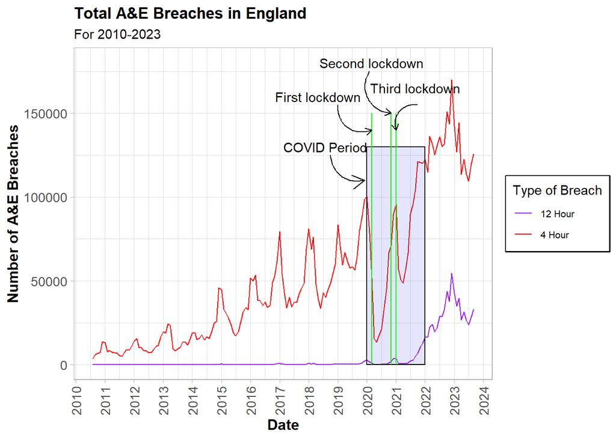

```r
# Creating our colours object
COLOURS <- c("4 Hour" = "red", "12 Hour" = "purple")

Legend_Breaches_Plot <- ggplot(Monthly_Data_Formatted) +
# We replace the colours in the aes() argument with their new names above
  geom_line(aes(x = `Period Formatted`, y = `4 Hour Breaches`, colour = "4 Hour"), size = 0.5) +
  geom_line(aes(x = `Period Formatted`, y = `12 Hour Breaches`, colour = "12 Hour"), size = 0.5) +
# Add the scale_colour_manual argument here
  scale_color_manual(values = COLOURS, name = "Type of Breach") +
  labs(title = "Total A&E Breaches in England",
       subtitle = "For 2010-2023",
       x = "Date",
       y = "Number of A&E Breaches") +
  scale_x_date(date_labels = "%Y", date_breaks = "1 year")+
  annotate('rect', xmin = as.Date("2020-01-01"), xmax = as.Date("2021-12-31"), ymin = 0, ymax = 130000,
           alpha = 0.1, fill = "blue", col = "black") +
  annotate('text', x = as.Date("2018-08-01"), y = 130000, label = "COVID Period") +
# We use 'annotate' again and using the same syntax as the box we now define the arrow's curve and length
   annotate('curve', x = as.Date("2018-10-01"), xend = as.Date("2019-12-01"),
            y = 125000, yend = 110000, linewidth = 0.5, curvature = 0.5,
             arrow = arrow(length = unit(0.4,'cm'))) +
# Below is the code for adding the vertical lines, again using the axes to determine their positions
  geom_segment(aes(x = as.Date("2020-03-01"), y = 0, yend = 150000,
                     xend = as.Date("2020-03-01"), colour = "segment"),
                     linewidth = 0.5, colour="green") +
  geom_segment(aes(x = as.Date("2020-11-01"), y = 0, yend = 150000,
                     xend = as.Date("2020-11-01"), colour = "segment"),
                     linewidth = 0.5, colour="green") +
  geom_segment(aes(x = as.Date("2021-01-01"), y = 0, yend = 150000,
                     xend = as.Date("2021-01-01"), colour = "segment"),
                     linewidth = 0.5, colour="green") +
# Here we add labels to distinguish the lines
  annotate('text',x = as.Date("2018-05-01"),y = 160000,label = "First lockdown") +
    annotate('text',x = as.Date("2020-03-01"),y = 180000,label = "Second lockdown") +
    annotate('text',x = as.Date("2021-09-01"),y = 165000,label = "Third lockdown") +
# And now add the arrows to make it clear which is which
   annotate('curve',x = as.Date("2019-01-01"),xend = as.Date("2020-03-01"), y = 155000, yend = 140000 ,
    linewidth = 0.5,curvature = 0.6,arrow = arrow(length = unit(0.2,'cm'))) +
     annotate('curve',x = as.Date("2020-02-01"),xend = as.Date("2020-11-01"), y = 175000, yend = 150000,
    linewidth = 0.5,curvature = 0.6,arrow = arrow(length = unit(0.2,'cm'))) +
   annotate('curve',x = as.Date("2021-10-01"),xend = as.Date("2021-01-01"), y = 155000 , yend = 140000,
    linewidth = 0.5,curvature = 0.6,arrow = arrow(length = unit(0.2,'cm'))) +
# We can start by adding a type of theme here, in this case 'light'
  theme_light() +
# Now we can add the legend and title details
  theme(plot.title = element_text(size = 13, face = 'bold') ,
        plot.subtitle = element_text(size = 11),
        axis.title = element_text(size = 12, face = 'bold'),
        axis.text.x = element_text(size = 10.5, angle = 90, vjust = 0.5, hjust = 1),
        axis.text.y = element_text(size = 10.5),
        legend.box.background = element_rect(colour = "black", linewidth = 1),
        legend.box.just = c("right", "top"),
        legend.text = element_text(size = 8))


Legend_Breaches_Plot
```